# Does_Z_Equal_Ls

Benjamin Draves

10/9/2019

# Analytic Walk Through

Here, we’re looking to see if there is a difference between the Adjacency Spectral Embedding (ASE) of $\tilde{\mathbf{P}}$, $\mathbf{Z} = \text{ASE}(\tilde{\mathbf{P}}, d)$ and our own constructed matrix
$$\begin{align*}
\mathbf{L}_S = \begin{bmatrix}
\mathbf{XS}^{(1)}\\
\mathbf{XS}^{(2)}\\
\vdots\\
\mathbf{XS}^{(m)}
\end{bmatrix}
\end{align*}$$
We’ve constructed the scaling matrices $\mathbf{S}^{(g)}$ such that
$$\begin{align*}
\mathbf{L}_S\mathbf{L}_S^T = \sum_{j = 1}^d \mathbf{H}^{+}(\mathbf{v}_j) \otimes \mathbf{X}_{\cdot j }\mathbf{X}_{\cdot j }^T
\end{align*}$$
Where $\mathbf{H}^{+}(\mathbf{v}_j)$ denotes the outer product rank one spectral embedding of $\mathbf{H}(\mathbf{v}_j)$. We have also shown that $\mathbf{L}_S\mathbf{L}_S^T$ is positive definite and that
$$\begin{align*}
\tilde{\mathbf{P}} =\mathbf{L}_S\mathbf{L}_S^T - \tilde{\mathbf{L}}_S\tilde{\mathbf{L}}_S^T
\end{align*}$$
Where
$$\begin{align*}
\tilde{\mathbf{L}}_S\tilde{\mathbf{L}}_S^T = \sum_{j = 1}^d \mathbf{H}^{-}(\mathbf{v}_j) \otimes \mathbf{X}_{\cdot j }\mathbf{X}_{\cdot j }^T
\end{align*}$$
Where $\mathbf{H}^{+}(\mathbf{v}_j)$ denotes the outer product vector perpendicular to the rank 1 adjacency spectral embedding of $\mathbf{H}(\mathbf{v}_j)$. Therefore, we see that $\tilde{\mathbf{P}}^{+} = \mathbf{L}_S\mathbf{L}_S^T$ is a positive defininite matrix and $\tilde{\mathbf{P}}^{-} = \tilde{\mathbf{L}}_S\tilde{\mathbf{L}}_S^T$ is positive semidefinite with $\mathbf{\tilde{P}} = \mathbf{\tilde{P}}^{+} - \mathbf{\tilde{P}}^{-}$. From here Horn and Johnson state that
$$\begin{align*}
\lambda(\mathbf{ZZ}^T) = \lambda(\mathbf{L}_S\mathbf{L}_S^T)
\end{align*}$$
I don’t think that’s entirely true… Consider a rank $4$ matrix $\mathbf{M}$ with 2 positive eigenvalues and two negative eigenvalues (as with $\tilde{\mathbf{P}}$ when $d = 2$). Then for some $c\in\mathbb{R}_+$ for $\delta = \min_i|\lambda_i(\mathbf{M})|$ we have
$$\begin{align*}
\mathbf{M} = \mathbf{M}^{+} - \mathbf{M}^{-} = (\mathbf{M}^{+} +\lambda\mathbf{I}) - (\mathbf{M}^{-} + \lambda\mathbf{I})
\end{align*}$$
Then
$$\begin{align*}
&\lambda_{1}(\mathbf{M}^{+}) = \lambda_1\quad \quad &&\lambda_{2}(\mathbf{M}^{+}) = \lambda_2\\
&\lambda_{1}(\mathbf{M}^{+} + c\mathbf{I}) = \lambda_1 + c\quad \quad &&\lambda_{2}(\mathbf{M}^{+}+c\mathbf{I}) = \lambda_2+c
\end{align*}$$
Similarly
$$\begin{align*}
&\lambda_{3}(\mathbf{M}^{-}) = |\lambda_3|\quad \quad &&\lambda_{4}(\mathbf{M}^{-}) = |\lambda_4|\\
&\lambda_{3}(\mathbf{M}^{-} + c\mathbf{I}) = |\lambda_3| + c\quad \quad &&\lambda_{4}(\mathbf{M}^{+}+c\mathbf{I}) = |\lambda_4|+c
\end{align*}$$

From this we see that $\mathbf{M}$ can still be factored into a difference of positive definite matrices. But this decomposition is not unique.

In this example, however, we see that $\mathbf{M}$ was written as a difference between matrices with a larger rank (i.e. rank $n$). I believe the statement is true if you require that the rank of each component be less than or equal to the rank of $\mathbf{M}$ this would be a true statement.

# Eigenvalue Difference

Going back to our main issue, we see that by construction $\mathbf{ZZ}^T$ and $\mathbf{L}_S\mathbf{L}_S^T$ are both rank $d$. Therefore Proposition 4.1.13 should apply (maybe?). Let’s test it.

First we set up some useful functions.

```r
#-----------------------------------------
#
#    Set up of Useful Functions
#
#-----------------------------------------
source("~/Documents/Work/github/BJSE/multiple_network_methods/code/basic_functions.R")
library(ggplot2); library(dplyr)
rotate <- function(target = X, input = Y){
  tmp <- svd(crossprod(target,input))
  W <- tcrossprod(tmp$v, tmp$u)
  return(input %*% W)

}
Wtil <- function(left, right, d){
  U_L <- eigen(left)$vectors[,1:d]
  U_R <- eigen(left)$vectors[,1:d]
  W1_Sigma_W2 <- svd(crossprod(U_L, U_R))

  W_til <- tcrossprod(W1_Sigma_W2$u, W1_Sigma_W2$v)

}
get_pd <- function(A, d) tcrossprod(ase(A, d))
```

Next we set up the classic 2 block SBM and choose a scaling matrix parameterized by $t$ as
$$\begin{align*}
\mathbf{C}(t) = \begin{bmatrix}
t + 1 & 0 \\
0 & 1 - t
\end{bmatrix}
\end{align*}$$

```r
#-----------------------------------------
#
#    Set up of Base Model
#
#-----------------------------------------

#set up blocks
B <- matrix(c(.25, .05, .05, .25), byrow = T, nrow = 2)
b_ase <- ase(B, 2)

#get latent positions
x1 <- b_ase[1,]; x2 <- b_ase[2,]

#set prior probabilities
pi <- .5

#get rotation (eigenvectors of Delta)
Delta <- pi * tcrossprod(x1) + (1 - pi)*tcrossprod(x2)
R <- eigen(Delta)$vectors

#Apply rotation to x1 and x2
x1_til <- t(R) %*% x1
x2_til <- t(R) %*% x2

#set base latent positions
L <- rbind(t(x1_til), t(x2_til))

#-----------------------------------------
#
#     Set up C values & Scaling Matrices
#
#-----------------------------------------

#converges to ER with p = .3 (1,1) --> (2,0)
C <- function(t){
  diag(c(t + 1, -t + 1))
}


S <- function(C){
  #bias matrices
  v1 <- c(1, C[1,1])
  v2 <- c(1, C[2,2])

  #get embeddings
  a1 <- ase(H1(v1), 1)[,1]
  a2 <- ase(H1(v2), 1)[,1]

  #define scaling matrices
  S1 <- diag(c(a1[1], a2[1]))
  S2 <- diag(c(a1[2], a2[2]))

  #return results
  return(list(S1, S2))
}
```

Next we run a simulation to see if indeed $\lambda(\mathbf{ZZ}^T) = \lambda(\mathbf{L}_S\mathbf{L}_S^T)$.

```r
#simulation parameters
n.t <- 20
t <- seq(0, 1, length.out = n.t)
mc_runs <- 10
n <- 500
```

We let $t\in[0,1]$ take on 20 different values. We consider networks of size 500 and we compare the eigenvalues of interest. We compare this for 10 number of iterations.

```r
#-----------------------------------------
#
#     Simulate To attain differences
#
#-----------------------------------------

#set seed
set.seed(1985)


#data structure
df <- matrix(NA, ncol = 6, nrow = n.t * mc_runs)
colnames(df) <- c("Sim_Number", "t", "Com_Balance", "Value_Difference", "Vector_Difference", "Zrot_Difference")
here <- 1


for(i in 1:n.t){
  for(j in 1:mc_runs){
  #sample rows of X
  samp <- sample(1:2, n, replace = TRUE)
  X <- L[samp, ]

  #get community balance
  cb <- unname(prop.table(table(samp))[1])

  #get P matrices
  P1 <- tcrossprod(X)
  P2 <- tcrossprod(X, X %*% C(t[i]))

  #get Z, Ls, and rotate Z
  Z <- ase(make_omni(list(P1, P2)), 2)
  Ls <- rbind(X %*% S(C(t[i]))[[1]], X %*% S(C(t[i]))[[2]])
  Z.rot <- rotate(target = Ls, input = Z)

  #calculate differences
  d1 <- norm2(eigen(tcrossprod(Z), only.values = TRUE)$values -  eigen(tcrossprod(Ls), only.values = TRUE)$values)
  d2 <- norm(tcrossprod(Z)- tcrossprod(Ls), type = "F")
  d3 <- norm(Z.rot- Ls, type = "F")

  #store results
  df[here, ] <- c(j, t[i], cb, d1, d2, d3)

  #update pointer
  here <- here + 1
  }
}
```

Next we visualize the results of this simulation.

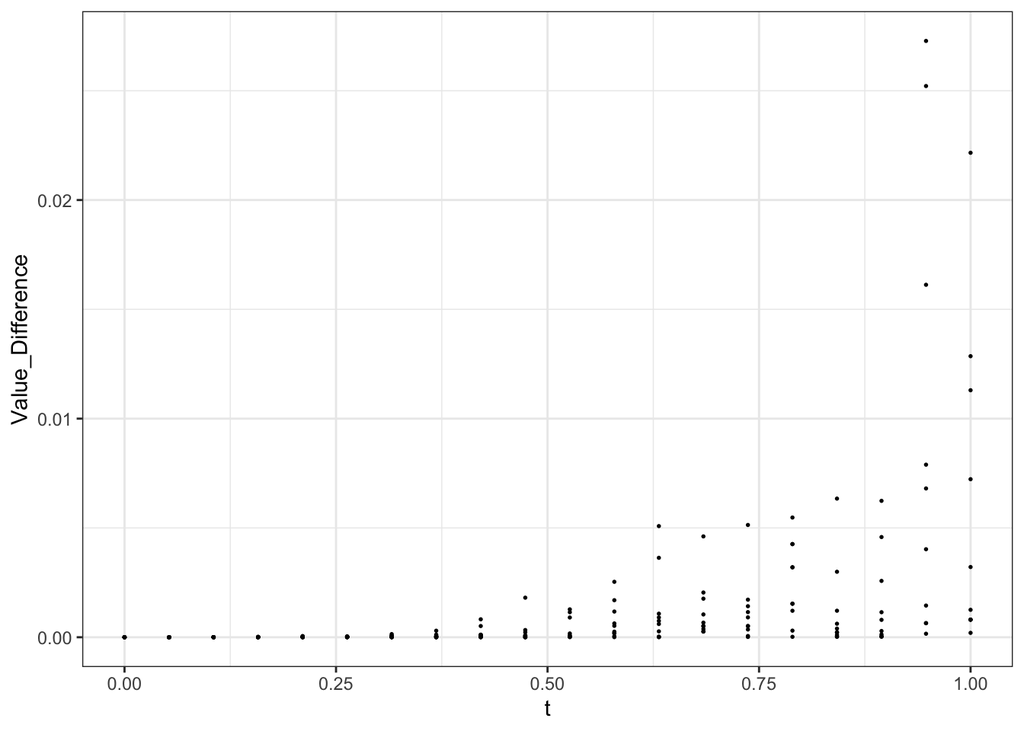

```r
plotdf <- as.data.frame(df)

#----------------------
#eigenvalue difference
#----------------------

#x = t
ggplot(plotdf, aes(t, Value_Difference)) +
  geom_point(size = .3)+
  theme_bw()
```

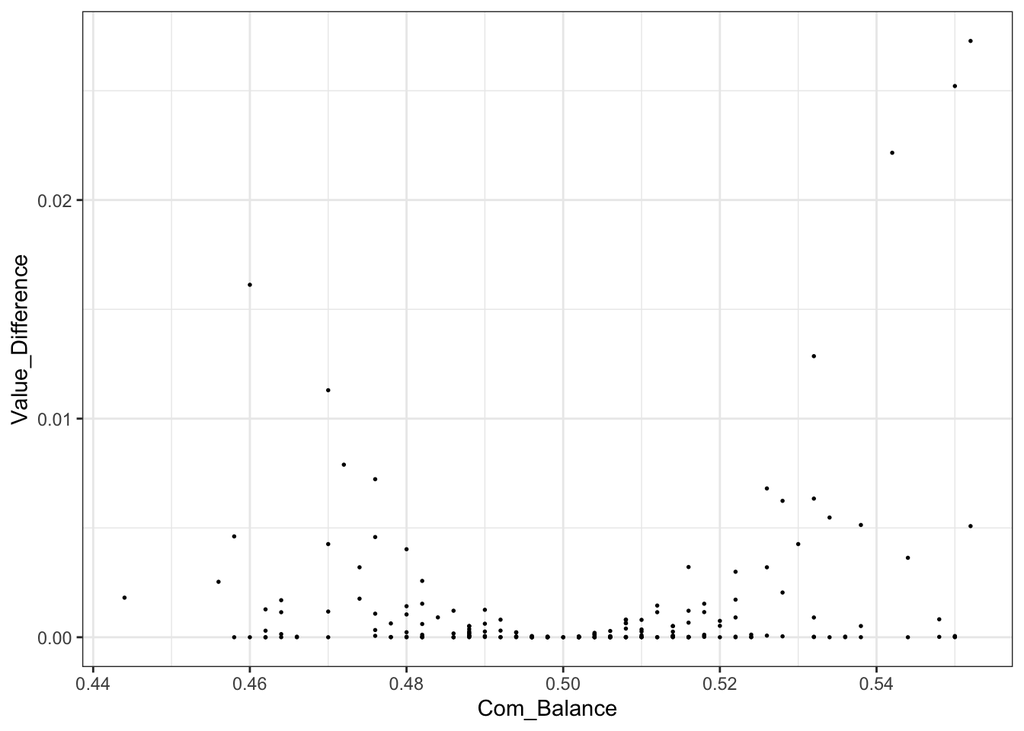

```r
#x = cb
ggplot(plotdf, aes(Com_Balance, Value_Difference)) +
  geom_point(size = .3)+
  theme_bw()
```

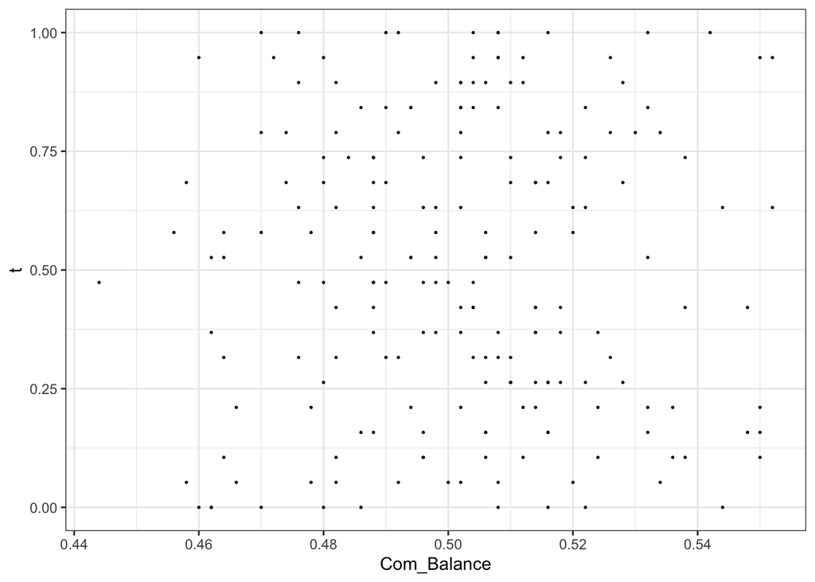

```r
#t against cb
ggplot(plotdf, aes(Com_Balance, t)) +
  geom_point(size = .3)+
  theme_bw()
```

So it looks like the eigenvalues are different. Specifically when $V\neq I$ we see that this equivalence is false…!

# Eigenvector Difference and Z - Ls

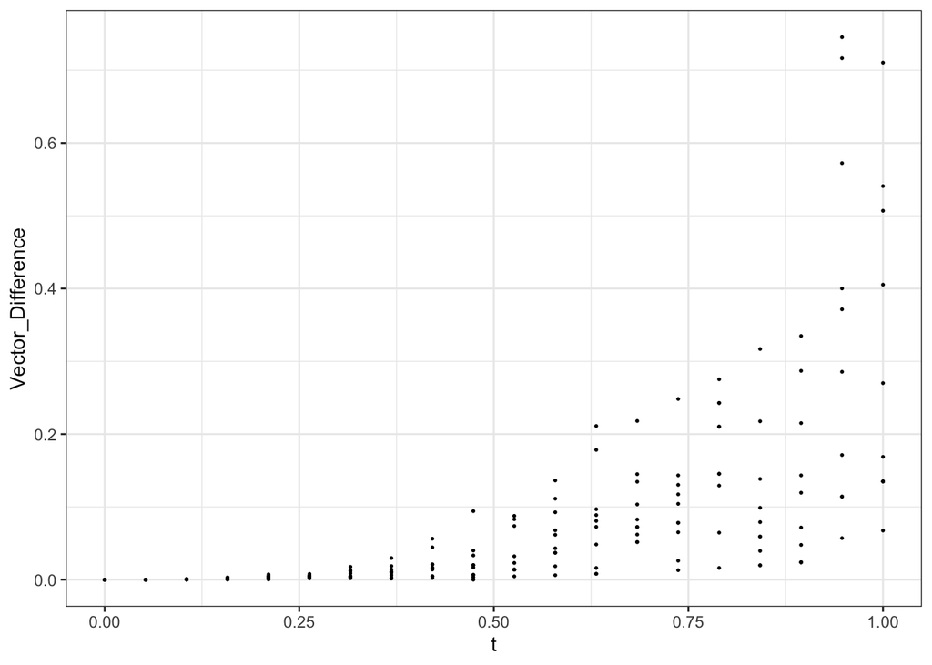

```r
#----------------------
#eigenvector difference
#----------------------

#x = t
ggplot(plotdf, aes(t, Vector_Difference)) +
  geom_point(size = .3)+
  theme_bw()
```

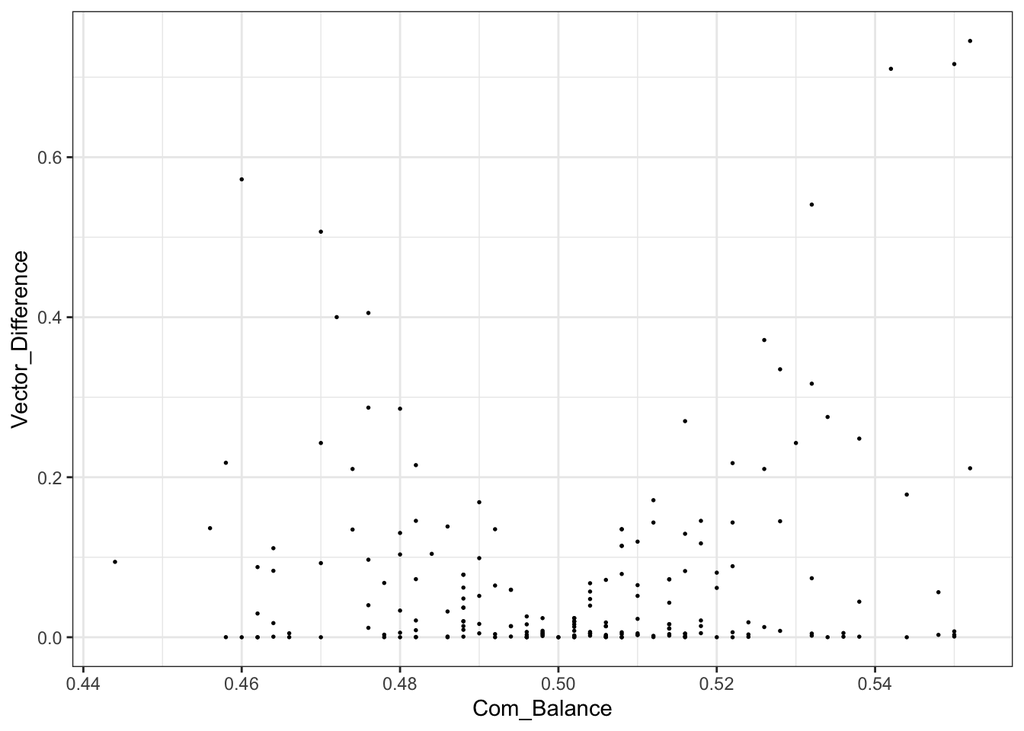

```r
#x = cb
ggplot(plotdf, aes(Com_Balance, Vector_Difference)) +
  geom_point(size = .3)+
  theme_bw()
```

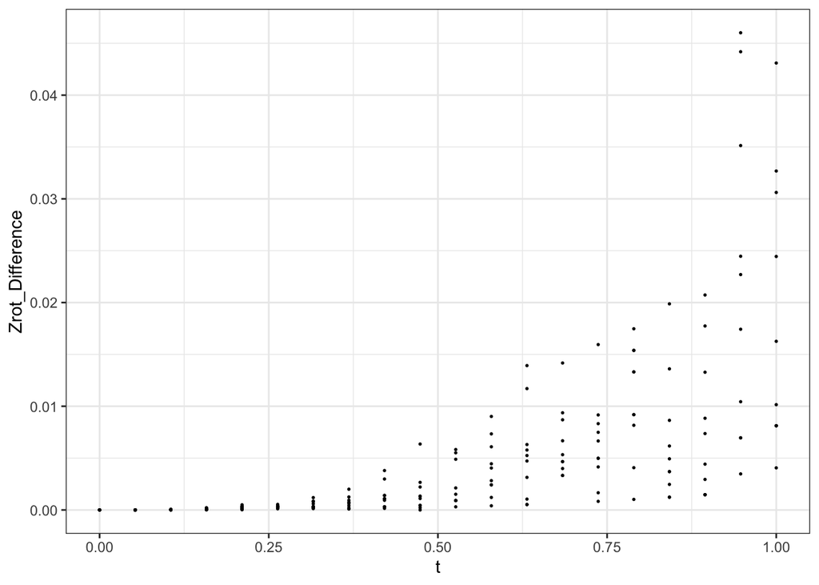

```r
#----------------------
#Z - Ls difference
#----------------------

#x = t
ggplot(plotdf, aes(t, Zrot_Difference)) +
  geom_point(size = .3)+
  theme_bw()
```

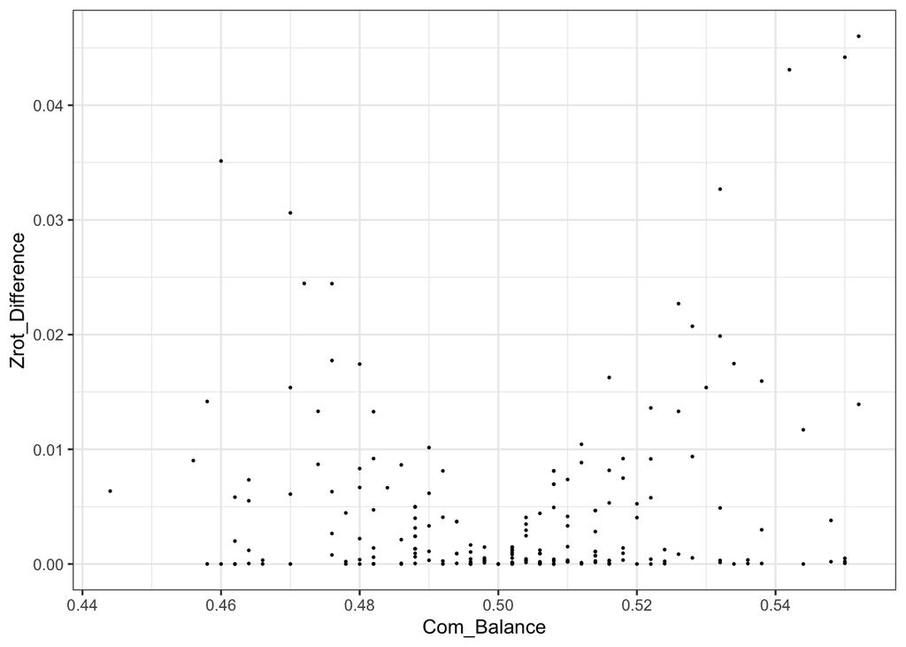

```r
#x = cb
ggplot(plotdf, aes(Com_Balance, Zrot_Difference)) +
  geom_point(size = .3)+
  theme_bw()
```

# Average Differences and Z - Ls

```r
plotdf <- as.data.frame(df) %>%
  group_by(t) %>%
  summarize(dvalue = mean(Value_Difference),
            sdvalues = sd(Value_Difference),
            dvector = mean(Vector_Difference),
            sdvector = sd(Vector_Difference),
            drot = mean(Zrot_Difference),
            sdrot = sd(Zrot_Difference),
            com.balance = mean(Com_Balance))
```

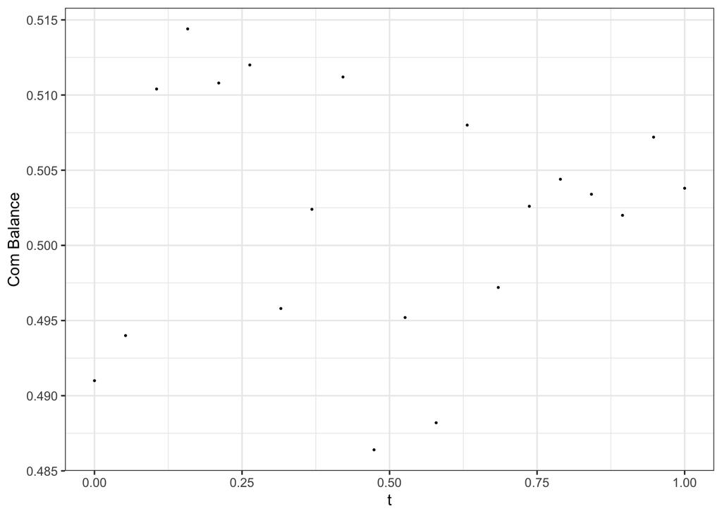

```r
#values plot
ggplot(plotdf, aes(t, com.balance)) +
  geom_point(size = .3)+
  theme_bw()+
  labs(x = "t", y = "Com Balance")
```

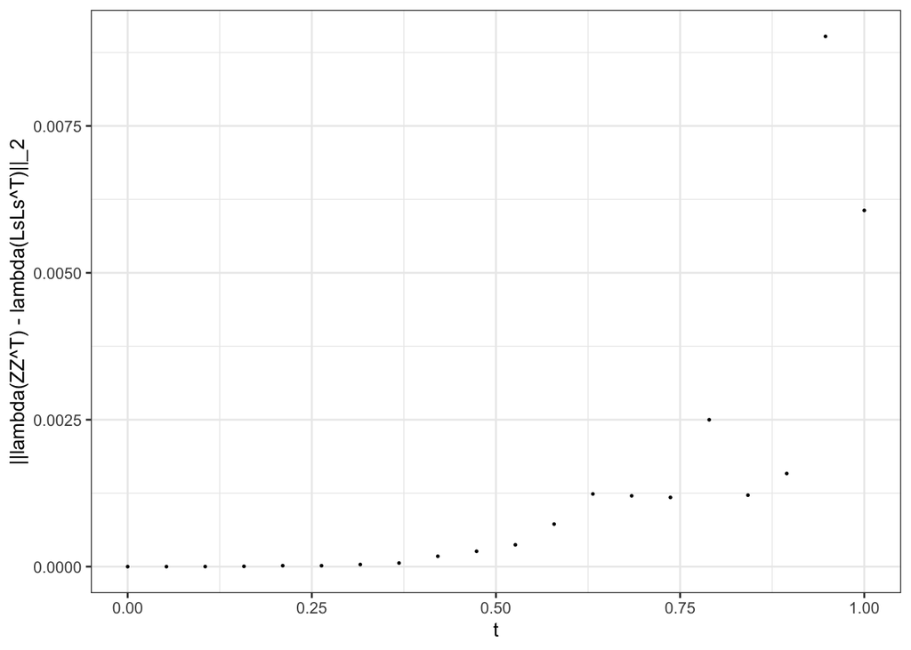

```r
#values plot
ggplot(plotdf, aes(t, dvalue)) +
  geom_point(size = .3)+
  theme_bw()+
    labs(x = "t",y =  "||lambda(ZZ^T) - lambda(LsLs^T)||_2")
```

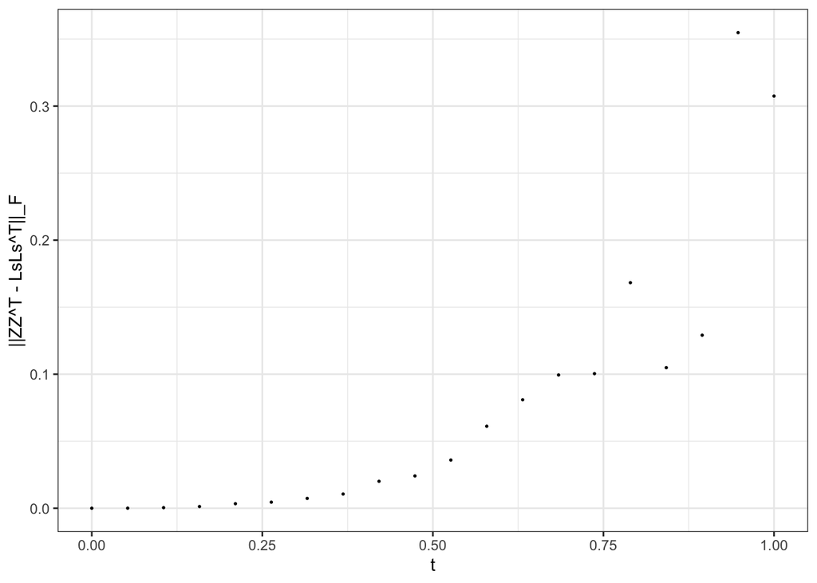

```r
#vectors plot
ggplot(plotdf, aes(t, dvector)) +
  geom_point(size = .3)+
  theme_bw()+
  labs(x = "t", y = "||ZZ^T - LsLs^T||_F")
```

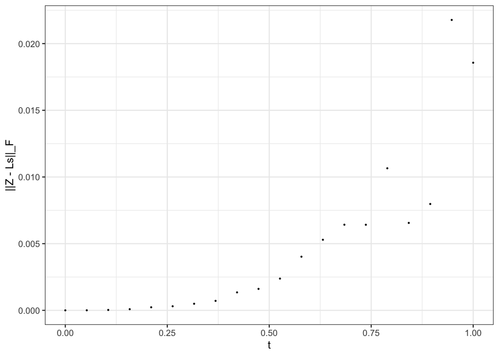

```r
ggplot(plotdf, aes(t, drot)) +
  geom_point(size = .3)+
  theme_bw()+
  labs(x = "t", y =  "||Z - Ls||_F")
```

Conclusion: Even when ``marginalizing out" $t$ is also driving the difference between $\mathbf{Z}$ and $\mathbf{L}_S$.